# An Analysis of Telecom Customer Churn

### Analyzed by Breton Shindel

### Dataset Provided by IMB Watson

# Overview

The following technical report is made to analyze IBM's Telecom Customer Churn dataset to derive insight into what factors lead to customer attrition in the telecommunications industry. My objective is twofold: to predict what customers are at highest risk of churn, and to determine what factors most strongly relate to churn. There are several steps in a full churn analysis that this report will not cover:

- Idenfitying a proper risk *score* for each customer, along with an intervention threshold
- Categorizing or regressing customers to determine which are savable, and which will churn inevitably (due to market conditions, company goals).
- Detailed analysis of each varible to determine underlying causes of customer churn.
- Pulling external data to improve models

### Below is the Telco Customer Churn dataset:

```python
from IPython.display import HTML

HTML('''<script>
code_show=true;
function code_toggle() {
 if (code_show){
 $('div.input').hide();
 } else {
 $('div.input').show();
 }
 code_show = !code_show
}
$( document ).ready(code_toggle);
</script>
<form action="javascript:code_toggle()"><input type="submit" value="Click here to toggle on/off the raw code."></form>''')
```

```python
import pandas as pd
import pandasql as pdsql
import numpy as np
import matplotlib.pyplot as plt
import seaborn as sns
import warnings

warnings.filterwarnings('ignore')
```

```python
%matplotlib inline

sns.set_context('poster')
sns.mpl.rc("figure", figsize=(12,8))
```

```python
Churn = pd.read_csv('WA_Fn-UseC_-Telco-Customer-Churn.csv')

pd.set_option('display.max_columns', None)

print('Number of observations:', Churn.shape[0])
print('Number of attributes:', Churn.shape[1])
Churn.head(5)
```

```
Number of observations: 7043
Number of attributes: 21
```

|  | customerID | gender | SeniorCitizen | Partner | Dependents | tenure | PhoneService | MultipleLines | InternetService | OnlineSecurity | OnlineBackup | DeviceProtection | TechSupport | StreamingTV | StreamingMovies | Contract | PaperlessBilling | PaymentMethod | MonthlyCharges | TotalCharges | Churn |
| --- | --- | --- | --- | --- | --- | --- | --- | --- | --- | --- | --- | --- | --- | --- | --- | --- | --- | --- | --- | --- | --- |
| 0 | 7590-VHVEG | Female | 0 | Yes | No | 1 | No | No phone service | DSL | No | Yes | No | No | No | No | Month-to-month | Yes | Electronic check | 29.85 | 29.85 | No |
| 1 | 5575-GNVDE | Male | 0 | No | No | 34 | Yes | No | DSL | Yes | No | Yes | No | No | No | One year | No | Mailed check | 56.95 | 1889.5 | No |
| 2 | 3668-QPYBK | Male | 0 | No | No | 2 | Yes | No | DSL | Yes | Yes | No | No | No | No | Month-to-month | Yes | Mailed check | 53.85 | 108.15 | Yes |
| 3 | 7795-CFOCW | Male | 0 | No | No | 45 | No | No phone service | DSL | Yes | No | Yes | Yes | No | No | One year | No | Bank transfer (automatic) | 42.30 | 1840.75 | No |
| 4 | 9237-HQITU | Female | 0 | No | No | 2 | Yes | No | Fiber optic | No | No | No | No | No | No | Month-to-month | Yes | Electronic check | 70.70 | 151.65 | Yes |

```python
print('There is no missing data:')
Churn.isnull().sum()
```

```
There is no missing data:
```

```
customerID          0
gender              0
SeniorCitizen       0
Partner             0
Dependents          0
tenure              0
PhoneService        0
MultipleLines       0
InternetService     0
OnlineSecurity      0
OnlineBackup        0
DeviceProtection    0
TechSupport         0
StreamingTV         0
StreamingMovies     0
Contract            0
PaperlessBilling    0
PaymentMethod       0
MonthlyCharges      0
TotalCharges        0
Churn               0
dtype: int64
```

# Translating the Dataset into Machine-Readable Structure:

There doesn't appear to be any necessary cleaning to do with the file, so we can move forward to the next step. Most modeling techniques will work best if the data attributes are converted to numerical form, is normalized, and does not assign ordinal value to nominal data. Once this translation step is complete, we will move begin modeling the data to predict customer attrition.

```python
from sklearn.preprocessing import LabelEncoder
from sklearn.preprocessing import StandardScaler

encoder = LabelEncoder()
Contract_Encode = pd.DataFrame(encoder.fit_transform(Churn['Contract'].values))
Churn_Encode = pd.DataFrame(encoder.fit_transform(Churn['Churn'].values))

Contract_Encode.rename(columns={0:'Contract'}, inplace=True)
Churn_Encode.rename(columns={0:'Churn'}, inplace=True)

OneHotEn_df = pd.get_dummies(Churn[['gender', 'Partner', 'Dependents', 'PhoneService', 'MultipleLines',
                                    'InternetService', 'OnlineSecurity', 'OnlineBackup', 'DeviceProtection',
                                    'TechSupport', 'StreamingTV', 'StreamingMovies', 'PaperlessBilling',
                                    'PaymentMethod']])

Remaining_df = Churn[['SeniorCitizen', 'tenure', 'MonthlyCharges']]

stdsc = StandardScaler()
Remaining_df.iloc[:,2] = stdsc.fit_transform(Remaining_df.iloc[:,2])
```

```python
Proc_Data = pd.concat([Contract_Encode, OneHotEn_df, Remaining_df, Churn_Encode], axis=1)
```

```python
print('Number of observations:', Proc_Data.shape[0])
print('Number of attributes:', Proc_Data.shape[1])
Proc_Data.head(5)
```

```
Number of observations: 7043
Number of attributes: 43
```

|  | Contract | gender_Female | gender_Male | Partner_No | Partner_Yes | Dependents_No | Dependents_Yes | PhoneService_No | PhoneService_Yes | MultipleLines_No | MultipleLines_No phone service | MultipleLines_Yes | InternetService_DSL | InternetService_Fiber optic | InternetService_No | OnlineSecurity_No | OnlineSecurity_No internet service | OnlineSecurity_Yes | OnlineBackup_No | OnlineBackup_No internet service | OnlineBackup_Yes | DeviceProtection_No | DeviceProtection_No internet service | DeviceProtection_Yes | TechSupport_No | TechSupport_No internet service | TechSupport_Yes | StreamingTV_No | StreamingTV_No internet service | … |
| --- | --- | --- | --- | --- | --- | --- | --- | --- | --- | --- | --- | --- | --- | --- | --- | --- | --- | --- | --- | --- | --- | --- | --- | --- | --- | --- | --- | --- | --- | --- |
| 0 | 0 | 1.0 | 0.0 | 0.0 | 1.0 | 1.0 | 0.0 | 1.0 | 0.0 | 0.0 | 1.0 | 0.0 | 1.0 | 0.0 | 0.0 | 1.0 | 0.0 | 0.0 | 0.0 | 0.0 | 1.0 | 1.0 | 0.0 | 0.0 | 1.0 | 0.0 | 0.0 | 1.0 | 0.0 | … |
| 1 | 1 | 0.0 | 1.0 | 1.0 | 0.0 | 1.0 | 0.0 | 0.0 | 1.0 | 1.0 | 0.0 | 0.0 | 1.0 | 0.0 | 0.0 | 0.0 | 0.0 | 1.0 | 1.0 | 0.0 | 0.0 | 0.0 | 0.0 | 1.0 | 1.0 | 0.0 | 0.0 | 1.0 | 0.0 | … |
| 2 | 0 | 0.0 | 1.0 | 1.0 | 0.0 | 1.0 | 0.0 | 0.0 | 1.0 | 1.0 | 0.0 | 0.0 | 1.0 | 0.0 | 0.0 | 0.0 | 0.0 | 1.0 | 0.0 | 0.0 | 1.0 | 1.0 | 0.0 | 0.0 | 1.0 | 0.0 | 0.0 | 1.0 | 0.0 | … |
| 3 | 1 | 0.0 | 1.0 | 1.0 | 0.0 | 1.0 | 0.0 | 1.0 | 0.0 | 0.0 | 1.0 | 0.0 | 1.0 | 0.0 | 0.0 | 0.0 | 0.0 | 1.0 | 1.0 | 0.0 | 0.0 | 0.0 | 0.0 | 1.0 | 0.0 | 0.0 | 1.0 | 1.0 | 0.0 | … |
| 4 | 0 | 1.0 | 0.0 | 1.0 | 0.0 | 1.0 | 0.0 | 0.0 | 1.0 | 1.0 | 0.0 | 0.0 | 0.0 | 1.0 | 0.0 | 1.0 | 0.0 | 0.0 | 1.0 | 0.0 | 0.0 | 1.0 | 0.0 | 0.0 | 1.0 | 0.0 | 0.0 | 1.0 | 0.0 | … |

# Modeling the Data

Next I will split the data into train and test sets using the holdout method (80%/20%) and run several models onto the data to a best estimate of customer attrition.

```python
from sklearn.cross_validation import train_test_split

X, y = Proc_Data.iloc[:, :-1].values, Proc_Data.iloc[:, -1].values
X_train, X_test, y_train, y_test = train_test_split(X, y, test_size=0.2, random_state=0)
```

```python
print('For most models, we don\'t want to exceed', int(round(len(X_train)/10, 0)), 'parameters given our training data.')
print('\n')
print('Given that the training data only has 42 input features, this should not be a problem.')
print('We will not use regularization to reduce dimensionality')
```

```
For most models, we don't want to exceed 563 parameters given our training data.


Given that the training data only has 42 input features, this should not be a problem.
We will not use regularization to reduce dimensionality
```

## Logistic Regression

```python
from sklearn.linear_model import LogisticRegression
from sklearn.metrics import precision_score


lr = LogisticRegression(penalty='l2', C=1, random_state=0)
lr.fit(X_train, y_train)
ypred = pd.Series(lr.predict(X_test))

print('Logistic model accuracy: %.3f' % lr.score(X_test, y_test))
print('Logistic model precision: %.3f' % precision_score(y_true=y_test, y_pred=ypred))
```

```
Logistic model accuracy: 0.799
Logistic model precision: 0.643
```

```python
ypred = pd.DataFrame(ypred)
ypred.rename(columns={0:'Churn_Predict'}, inplace=True)

y_test = pd.DataFrame(y_test)
y_test.rename(columns={0:'Churn_True'}, inplace=True)

Comparative = pd.concat([ypred, y_test], axis=1)
print('Compare last 5 values:')
Comparative.tail()
```

```
Compare last 5 values:
```

|  | Churn_Predict | Churn_True |
| --- | --- | --- |
| 1404 | 1 | 1 |
| 1405 | 1 | 1 |
| 1406 | 0 | 1 |
| 1407 | 0 | 0 |
| 1408 | 0 | 0 |

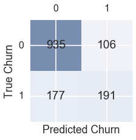

```python
from sklearn.metrics import confusion_matrix

confmat = confusion_matrix(y_true=y_test, y_pred=ypred)
fig, ax = plt.subplots(figsize=(3, 3))
ax.matshow(confmat, cmap=plt.cm.Blues, alpha=0.5)
for i in range(confmat.shape[0]):
    for j in range(confmat.shape[1]):
        ax.text(x=j, y=i, s=confmat[i, j], va='center', ha='center')
plt.xlabel('Predicted Churn')
plt.ylabel('True Churn')
plt.show();
```

## Random Forest

```python
from sklearn.ensemble import RandomForestClassifier

forest = RandomForestClassifier(criterion='entropy', n_estimators=100, random_state=1, n_jobs=2)
forest.fit(X_train, y_train)

print('Accuracy: %.3f' % forest.score(X_test, y_test))
```

[output not shown]

## KNN

```python
from sklearn.neighbors import KNeighborsClassifier

knn = KNeighborsClassifier(n_neighbors=100, p=5, metric='euclidean')
knn.fit(X_train, y_train)

print('Accuracy: %.3f' % knn.score(X_test, y_test))
```

[output not shown]

## SVM

```python
from sklearn.svm import SVC

svm = SVC(kernel = 'rbf', random_state=0, gamma=0.2, C=1)
svm.fit(X_train, y_train)

print('Accuracy: %.3f' % svm.score(X_test, y_test))
```

```
Accuracy: 0.792
```

## Ensemble Classifier

An ensemble classifier is designed to improve accuracy and precision by combining several classification models

```python
pred1 = pd.Series(lr.predict(X_test))
pred2 = pd.Series(forest.predict(X_test))
pred3 = pd.Series(knn.predict(X_test))
pred4 = pd.Series(svm.predict(X_test))
pred5 = pd.Series(lr.predict(X_test))
# this is an ameture way to do it, but I'm giving logistic twice the weight because of its reliability

predictions = pd.concat([pred1, pred2, pred3, pred4, pred5], axis=1)
```

```python
predictions['ensemble_pred'] = predictions.mode(axis=1)
```

```python
predictions.tail()
```

|  | 0 | 1 | 2 | 3 | 4 | ensemble_pred |
| --- | --- | --- | --- | --- | --- | --- |
| 1404 | 1 | 1 | 1 | 1 | 1 | 1 |
| 1405 | 1 | 1 | 1 | 0 | 1 | 1 |
| 1406 | 0 | 0 | 0 | 0 | 0 | 0 |
| 1407 | 0 | 0 | 0 | 0 | 0 | 0 |
| 1408 | 0 | 1 | 1 | 1 | 0 | 1 |

```python
Compare = pd.concat([predictions['ensemble_pred'], y_test], axis=1)
Compare.head()
```

|  | ensemble_pred | Churn_True |
| --- | --- | --- |
| 0 | 0 | 0 |
| 1 | 0 | 0 |
| 2 | 0 | 0 |
| 3 | 0 | 0 |
| 4 | 0 | 0 |

```python
Classification = pd.Series(Compare.ensemble_pred == Compare.Churn_True).astype(int)
Accuracy = ((Classification==1).sum()/len(Classification))

print('Ensemble accuracy: ', Accuracy)
```

```
Ensemble accuracy:  0.787083037615
```

The ensemble accuracy interestingly did not perform the best.

# Coming Soon: Explaining Why Customers Leave

At this time we can decently predict if a customer is going to discontinue service. The models have much potential to improve, particularly regarding their precision, but that's not important. The purpose of this analysis is to explain why customers leave, and help us diagnose ways to retain them. The next big question is: "how can we use this data to tell why our customers leave us?" I would take the following analytical steps to identify root causes of churn:

- Variable testing: use t-tests, chi square tests, and ANOVA on each variable compared to churn.
- Pull in data related to each variable and repeat tests above to identify correlations of each variable that correlates with churn.
- Identify which customers are likely to be saved and which are not. Model variables around data for the savable customers, so that we can identify the strongest factors to retain those that can be saved, rather than those that can't.